# A Visual History of Nobel Prize Winners

# 1. Introduction: History Nobel Prizes

[figure not shown]

The Nobel Prize is perhaps the worlds most well known scientific award. Except for the honor, prestige and substantial prize money the recipient also gets a gold medal showing Alfred Nobel (1833 - 1896) who established the prize. Every year it’s given to scientists and scholars in the categories chemistry, literature, physics, physiology or medicine, economics, and peace. The first Nobel Prize was handed out in 1901, and at that time the Prize was very Eurocentric and male-focused, but nowadays it’s not biased in any way whatsoever. Surely. Right?

Well, we’re going to find out! The Nobel Foundation has made a dataset available of all prize winners from the start of the prize, in 1901, to 2016. Let’s load it in and take a look.

# 2. About the Dataset

The dataset is available on Kaggle. The dataset contains only one file “archive.csv”. Link to the dataset - [here](https://www.kaggle.com/datasets/nobelfoundation/nobel-laureates)

## 2.1 Context

Between 1901 and 2016, the Nobel Prizes and the Prize in Economic Sciences were awarded 579 times to 911 people and organizations. The Nobel Prize is an international award administered by the Nobel Foundation in Stockholm, Sweden, and based on the fortune of Alfred Nobel, Swedish inventor and entrepreneur. In 1968, Sveriges Riksbank established The Sveriges Riksbank Prize in Economic Sciences in Memory of Alfred Nobel, founder of the Nobel Prize. Each Prize consists of a medal, a personal diploma, and a cash award.

A person or organization awarded the Nobel Prize is called Nobel Laureate. The word “laureate” refers to being signified by the laurel wreath. In ancient Greece, laurel wreaths were awarded to victors as a sign of honor.

# 3. Preparing the Data

### 3.1 Installing & Loading the required packages

```r
install.packages("tidyverse")
install.packages("lubridate")
library(tidyverse)
library(lubridate)
```

### 3.2 Loading the Data

```r
nobel <- read_csv("data/nobel.csv")
# Checking the data is working or not
head(nobel)
```

| year | category | prize | motivation | prize_share | laureate_id | laureate_type | full_name | birth_date | birth_city | birth_country | sex | organization_name | organization_city | organization_country | death_date | death_city | death_country |
| --- | --- | --- | --- | --- | --- | --- | --- | --- | --- | --- | --- | --- | --- | --- | --- | --- | --- |
| 1901 | Chemistry | The Nobel Prize in Chemistry 1901 | "in recognition of the extraordinary services he has rendered by the discovery of the laws of chemical dynamics and osmotic pressure in solutions" | 1/1 | 160 | Individual | Jacobus Henricus van 't Hoff | 1852-08-30 | Rotterdam | Netherlands | Male | Berlin University | Berlin | Germany | 1911-03-01 | Berlin | Germany |
| 1901 | Literature | The Nobel Prize in Literature 1901 | "in special recognition of his poetic composition, which gives evidence of lofty idealism, artistic perfection and a rare combination of the qualities of both heart and intellect" | 1/1 | 569 | Individual | Sully Prudhomme | 1839-03-16 | Paris | France | Male | NA | NA | NA | 1907-09-07 | Châtenay | France |
| 1901 | Medicine | The Nobel Prize in Physiology or Medicine 1901 | "for his work on serum therapy, especially its application against diphtheria, by which he has opened a new road in the domain of medical science and thereby placed in the hands of the physician a vic… | 1/1 | 293 | Individual | Emil Adolf von Behring | 1854-03-15 | Hansdorf (Lawice) | Prussia (Poland) | Male | Marburg University | Marburg | Germany | 1917-03-31 | Marburg | Germany |
| 1901 | Peace | The Nobel Peace Prize 1901 | NA | 1/2 | 462 | Individual | Jean Henry Dunant | 1828-05-08 | Geneva | Switzerland | Male | NA | NA | NA | 1910-10-30 | Heiden | Switzerland |
| 1901 | Peace | The Nobel Peace Prize 1901 | NA | 1/2 | 463 | Individual | Frédéric Passy | 1822-05-20 | Paris | France | Male | NA | NA | NA | 1912-06-12 | Paris | France |
| 1901 | Physics | The Nobel Prize in Physics 1901 | "in recognition of the extraordinary services he has rendered by the discovery of the remarkable rays subsequently named after him" | 1/1 | 1 | Individual | Wilhelm Conrad Röntgen | 1845-03-27 | Lennep (Remscheid) | Prussia (Germany) | Male | Munich University | Munich | Germany | 1923-02-10 | Munich | Germany |

# 4. Analyzing the Data

Just looking at the first couple of prize winners, or Nobel laureates as they are also called, we already see a celebrity: Wilhelm Conrad Röntgen, the guy who discovered X-rays. And actually, we see that all of the winners in 1901 were guys that came from Europe. But that was back in 1901, looking at all winners in the dataset, from 1901 to 2016, which sex and which country is the most commonly represented?

```r
nobel %>% count()
```

| n |
| --- |
| 911 |

### 4.2 What is the breakdown of the number of prizes won by male and female recipients?

```r
nobel %>%
  count(sex)
```

| sex | n |
| --- | --- |
| Female | 49 |
| Male | 836 |
| NA | 26 |

### 4.3 How many prizes have been won by recipients of different nationalities?

```r
nobel %>%
  count(birth_country) %>%
  arrange(desc(n)) %>%
  head(20)
```

| birth_country | n |
| --- | --- |
| United States of America | 259 |
| United Kingdom | 85 |
| Germany | 61 |
| France | 51 |
| Sweden | 29 |
| NA | 26 |
| Japan | 24 |
| Canada | 18 |
| Netherlands | 18 |
| Italy | 17 |

[output cut: 10 more lines]

**Note:** From above table we can see that the most common Nobel laureate between 1901 and 2016 was a man born in the United States of America. But in 1901 all the laureates were European. When did the USA start to dominate the Nobel Prize charts? Let’s check:

### 4.4 What is the proportion of winners born in the USA per decade?

```r
prop_usa_winners <- nobel %>%
  mutate(
    usa_born_winner = birth_country == "United States of America",
    decade = floor(year / 10) * 10
  ) %>%
  group_by(decade) %>%
  summarize(proportion = mean(usa_born_winner, na.rm = TRUE))

# Display the proportions of USA born winners per decade
prop_usa_winners
```

| decade | proportion |
| --- | --- |
| 1900 | 0.01785714 |
| 1910 | 0.07894737 |
| 1920 | 0.07407407 |
| 1930 | 0.25454545 |
| 1940 | 0.32500000 |
| 1950 | 0.29577465 |
| 1960 | 0.28000000 |
| 1970 | 0.32038835 |
| 1980 | 0.32978723 |
| 1990 | 0.41584158 |

[output cut: 2 more lines]

### 4.5 Who is the first woman to win the Nobel Prize and which catagory?

```r
nobel %>%
    filter(sex == "Female") %>%
    top_n(1, desc(year))
```

| year | category | prize | motivation | prize_share | laureate_id | laureate_type | full_name | birth_date | birth_city | birth_country | sex | organization_name | organization_city | organization_country | death_date | death_city | death_country |
| --- | --- | --- | --- | --- | --- | --- | --- | --- | --- | --- | --- | --- | --- | --- | --- | --- | --- |
| 1903 | Physics | The Nobel Prize in Physics 1903 | "in recognition of the extraordinary services they have rendered by their joint researches on the radiation phenomena discovered by Professor Henri Becquerel" | 1/4 | 6 | Individual | Marie Curie, née Sklodowska | 1867-11-07 | Warsaw | Russian Empire (Poland) | Female | NA | NA | NA | 1934-07-04 | Sallanches | France |

### 4.6 Who is the youngest winner of Nobel Prize as of 2016?

You can also find this name in this section.

```r
youngest_winner <- "Malala Yousafzai"
youngest_winner
```

```
[1] "Malala Yousafzai"
```

# 5. Data Visualization

From the above table illustration, we can see the proportion of Nobel Prize winners born in the USA per decade. We need a visualization so that we can determine the point in time when the USA started to dominate the Nobel Prize charts.

### 5.1 Plotting the winners who have been born in the US:

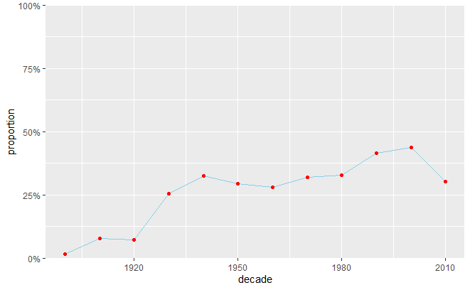

```r
ggplot(prop_usa_winners, aes(x = decade, y = proportion)) +
  geom_line(color = "skyblue") +
  geom_point(color = "red") +
  scale_y_continuous(labels = scales::percent, limits = 0:1, expand = c(0, 0))
ggsave("img/plot01.png", dpi=1000)
```

So, we can see that USA started dominating the charts from the 1930s and has kept the leading position ever since. Now let’s calculate the female winners per decade:

```r
prop_female_winners <- nobel %>%
    mutate(
        female_winner = sex == "Female",
        decade = floor(year / 10) * 10
    ) %>%
    group_by(decade, category) %>%
    summarize(proportion = mean(female_winner, na.rm = TRUE))
```

And finally visualizing the female winners per decade:

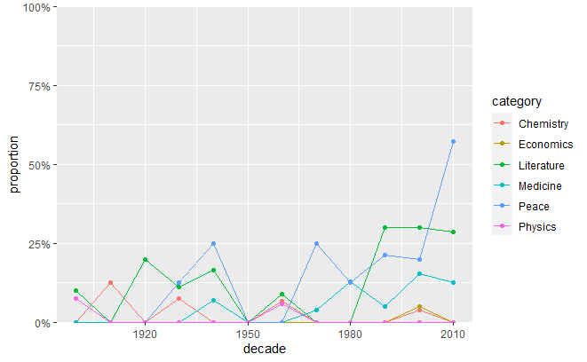

```r
ggplot(prop_female_winners, aes(x = decade, y = proportion, color = category)) +
  geom_line() +
  geom_point() +
  scale_y_continuous(labels = scales::percent, limits = 0:1, expand = c(0, 0))
ggsave("img/plot02.png", dpi=1000)
```

The plot above is a bit messy as the lines are overplotting. But it does show some interesting trends and patterns. Overall the imbalance is pretty large with physics, economics, and chemistry having the largest imbalance. Medicine has a somewhat positive trend, and since the 1990s the literature prize is also now more balanced. The big outlier is the peace prize during the 2010s, but keep in mind that this just covers the years 2010 to 2016.

### 5.2 Who is the Nobel Prize laureate who has won the award more than once?

For most scientists/writers/activists a Nobel Prize would be the crowning achievement of a long career. But for some people, one is just not enough, and there are few that have gotten it more than once. To find that:

```r
nobel %>%
  count(full_name) %>%
  filter(n > 1)
```

| full_name | n |
| --- | --- |
| Comité international de la Croix Rouge (International Committee of the Red Cross) | 3 |
| Frederick Sanger | 2 |
| John Bardeen | 2 |
| Linus Carl Pauling | 2 |
| Marie Curie, née Sklodowska | 2 |
| Office of the United Nations High Commissioner for Refugees (UNHCR) | 2 |

### 5.3 Age distribution of Nobel Prize Winners

To visualize the age distribution of the Nobel Prize laureate, first we need to calculate the age of individual winners.

```r
nobel_age <- nobel %>%
  mutate(age = year - year(birth_date))
```

After calculating the ages of the winners let’s plot the data for better understanding.

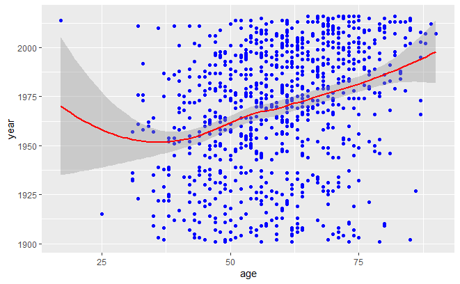

```r
ggplot(nobel_age, aes(x = age, y = year)) +
  geom_point(color = "blue") +
  geom_smooth(color = "red")
ggsave("img/plot03.png", dpi=1000)
```

The plot above shows us a lot! We see that people use to be around 55 when they received the price, but nowadays the average is closer to 65. But there is a large spread in the laureates’ ages, and while most are 50+, some are very young.

We also see that the density of points is much high nowadays than in the early 1900s – nowadays many more of the prizes are shared, and so there are many more winners. We also see that there was a disruption in awarded prizes around the Second World War (1939 - 1945).

### 5.4 Age differences between prize categories

In the previous plot we visualized the age distribution but it was not within different prize categories. So, let us visualize that:

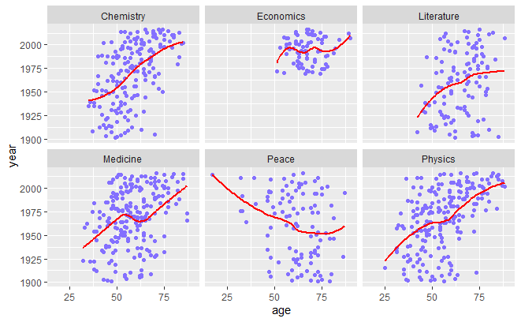

```r
ggplot(nobel_age, aes(x = age, y = year)) +
  geom_point(color = "lightslateblue") +
  geom_smooth(se = FALSE, color = "red") +
  facet_wrap(~ category)
ggsave("img/plot04.png", dpi=1000)
```

Another plot with lots of exciting stuff going on! We see that both winners of the chemistry, medicine, and physics prize have gotten older over time. The trend is strongest for physics: the average age used to be below 50, and now it’s almost 70. Literature and economics are more stable, and we also see that economics is a newer category.

### 5.5 Oldest and Youngest Winners

But notice, Peace shows an opposite trend where winners are getting younger!

In the peace category we also a winner around 2010 that seems exceptionally young. This begs the questions, who are the oldest and youngest people ever to have won a Nobel Prize?

#### 5.5.1 Oldest Winner of 2016

```r
# The oldest winner of a Nobel Prize as of 2016
nobel_age %>% top_n(1, age)
```

| year | category | prize | motivation | prize_share | laureate_id | laureate_type | full_name | birth_date | birth_city | birth_country | sex | organization_name | organization_city | organization_country | death_date | death_city | death_country | age |
| --- | --- | --- | --- | --- | --- | --- | --- | --- | --- | --- | --- | --- | --- | --- | --- | --- | --- | --- |
| 2007 | Economics | The Sveriges Riksbank Prize in Economic Sciences 2007 | "for having laid the foundations of mechanism design theory" | 1/3 | 820 | Individual | Leonid Hurwicz | 1917-08-21 | Moscow | Russia | Male | University of Minnesota | Minneapolis, MN | United States of America | 2008-06-24 | Minneapolis, MN | United States of America | 90 |

#### 5.5.2 Youngest Winner of 2016

```r
# The youngest winner of a Nobel Prize as of 2016
nobel_age %>% top_n(1, desc(age))
```

| year | category | prize | motivation | prize_share | laureate_id | laureate_type | full_name | birth_date | birth_city | birth_country | sex | organization_name | organization_city | organization_country | death_date | death_city | death_country | age |
| --- | --- | --- | --- | --- | --- | --- | --- | --- | --- | --- | --- | --- | --- | --- | --- | --- | --- | --- |
| 2014 | Peace | The Nobel Peace Prize 2014 | "for their struggle against the suppression of children and young people and for the right of all children to education" | 1/2 | 914 | Individual | Malala Yousafzai | 1997-07-12 | Mingora | Pakistan | Female | NA | NA | NA |  | NA | NA | 17 |

# 6. Conclusion

In conclusion, we have analyzed the Nobel Prize dataset from 1901 to 2016 and found some interesting insights. We saw that the USA started dominating the Nobel Prize charts from the 1930s and has kept the leading position ever since. We also observed that physics, economics, and chemistry have the largest imbalance in gender representation. We found out that Marie Curie is one of the few people who have won the award more than once, and we also visualized the age distribution of Nobel Prize winners over time. Finally, we discovered that Leonid Hurwicz was the oldest winner of a Nobel Prize as of 2016 while Malala Yousafzai was the youngest. Overall, this dataset provides a fascinating insight into one of the world’s most prestigious scientific awards and its history.